# Campus Water Quality: E. coli and Total Coliform

Marc Los Huertos

EA030 · Compiled 2026-04-24

EA030 — RTricks — Activity 19

# Campus Water Quality: E. coli, Total Coliform, and Colilert MPN

**Prof. Marc Los Huertos** • Pomona College • Environmental Analysis

← Back to RTricks

Background Colilert Method Data Pipeline Import & Clean Dilution Correction Visualise ANOVA Interpret Summary

#### 🎯 Learning Outcomes

1. Explain why *E. coli* and total coliform are used as indicator organisms for water quality, and describe the health risks associated with each.
2. Describe how the Colilert Quanti-Tray system produces MPN (Most Probable Number) estimates and why dilution correction is necessary.
3. Import the class Colilert data from a CSV export, standardise column names, and apply dilution correction factors to compute true MPN/100 mL.
4. Visualise MPN distributions across sampling sites and compare them to California Basin Plan recreational standards.
5. Run a one-way ANOVA and Kruskal-Wallis test to determine whether bacterial concentrations differ significantly among campus sites.
6. Interpret results in the context of campus hydrology and propose monitoring or management recommendations.

> **What this activity covers.** Each semester, EA030 students collect water samples from three campus sites — pHake Lake, Seal Court, and the Pomona Bioswale — and analyse them for *E. coli* and total coliform using the Colilert Quanti-Tray method. This module explains the biology behind the test, walks through the data pipeline from raw Colilert readings to corrected MPN/100 mL, and guides you through the statistical analysis of class results. The goal is not just to run a t-test on your own group’s two samples, but to analyse the entire class dataset — which gives enough replication to make meaningful statistical inferences about site differences.

## 1. Background: Why *E. coli*?

*Escherichia coli* (*E. coli*) is a bacterium found in the intestines of humans and warm-blooded animals, where most strains are harmless and aid digestion. However, its presence in water is a primary public health concern for two reasons.

**As an indicator organism.** *E. coli* itself is not always dangerous in water, but its presence signals **fecal contamination** — meaning the water has been in contact with human or animal waste. Where fecal matter goes, pathogenic organisms follow: *Cryptosporidium*, *Giardia*, *Salmonella*, *Hepatitis A*, and noroviruses all co-occur with fecal contamination and are far harder and more expensive to detect directly. Testing for *E. coli* is a fast, inexpensive proxy for the presence of the entire suite of fecal pathogens.

**As a direct pathogen.** Certain strains — especially O157:H7 (Shiga-toxin-producing *E. coli*, STEC) — cause severe illness including haemorrhagic diarrhoea, urinary tract infections, and haemolytic uraemic syndrome (HUS), which can cause kidney failure and death. These strains enter water through agricultural runoff from cattle operations, sewage spills, and stormwater overflows.

### Sources of fecal contamination on and near the Pomona campus

The three sampling sites capture distinct potential contamination pathways:

| Site | Potential sources |
| --- | --- |
| **pHake Lake** | Waterfowl (geese, ducks) — major fecal contributors; irrigation return flow; adjacent lawn runoff |
| **Seal Court** | Urban stormwater from hardscaped surfaces; pet waste; adjacent building drain connections |
| **Pomona Bioswale** | Designed to filter runoff — acts as a treatment system; captures street and parking lot runoff before it enters groundwater |

**📌 Total coliform vs. *E. coli* — what’s the difference?** **Total coliform** includes a broader group of bacteria in the family Enterobacteriaceae (including *E. coli*, *Klebsiella*, and *Enterobacter*). Some are environmental organisms that do not indicate fecal contamination — they naturally inhabit soil and plant matter. *E. coli* is a subset of total coliform that is almost exclusively fecal in origin. This is why regulatory standards for drinking water use *E. coli* as the indicator, while total coliform is used as a more sensitive screening test: if total coliform is absent, *E. coli* cannot be present, and no further testing is needed.

### Regulatory standards

| Use | Standard | Regulation |
| --- | --- | --- |
| Contact recreation (swimming) | 320 MPN/100 mL (single sample) | CA Basin Plan REC-1 |
| Contact recreation (geometric mean) | 100 MPN/100 mL | CA Basin Plan REC-1 |
| Non-contact recreation | 1,000 MPN/100 mL | CA Basin Plan REC-2 |
| Drinking water | 0 (any detection) | EPA SDWA / SWTR |

## 2. The Colilert Method

### 2.1 How Colilert works

Colilert (IDEXX Laboratories) is an enzyme-substrate method that simultaneously detects total coliform and *E. coli* in a single test. The reagent contains two chromogenic substrates:

- **ONPG** (ortho-nitrophenyl-β-D-galactopyranoside) — cleaved by β-galactosidase, an enzyme produced by total coliform. Produces a **yellow colour** visible to the naked eye.
- **MUG** (4-methylumbelliferyl-β-D-glucuronide) — cleaved by β-glucuronidase, an enzyme produced almost exclusively by *E. coli*. Produces **blue fluorescence** under a 365 nm UV lamp.

The sample is sealed in an IDEXX Quanti-Tray — a plastic tray with 97 large wells and 48 small wells — and incubated at 35°C for 24 hours. After incubation, you count the number of yellow (total coliform) and fluorescent (E. coli) wells and use the IDEXX MPN table to convert well counts to MPN/100 mL.

Step 1

Collect sample

100 mL in sterile bottle. Keep cold, analyse within 6 hours. If turbid, dilute 1:10 with sterile water.

Step 2

Add Colilert

Add one Colilert reagent sachet to the 100 mL sample. Mix until dissolved.

Step 3

Seal tray

Pour reagent mixture into a Quanti-Tray. Heat-seal with the Quanti-Tray Sealer. Label with site and time.

Step 4

Incubate & read

35°C ± 0.5°C for 24–28 hours. Count yellow wells (TC) and fluorescent wells (EC) under UV lamp.

### 2.2 The MPN concept

MPN (Most Probable Number) is a statistical estimate of microbial density based on the pattern of positive (enzyme-active) and negative wells. It is not a direct count — it is the bacterial concentration most likely to produce the observed pattern of positives. The Quanti-Tray system uses a maximum-likelihood algorithm to convert the (large positive wells, small positive wells) pair to an MPN/100 mL value.

**⚙️ MPN and dilution correction.** If a sample was too turbid to analyse undiluted, it is diluted 1:10 before adding Colilert. The Quanti-Tray then sees only 1/10 of the original bacteria. To recover the true concentration:  
MPN<sub>corrected</sub> = MPN<sub>raw</sub> × dilution factor  
A raw reading of 450 MPN/100 mL from a 1:10 diluted sample represents a true concentration of 4,500 MPN/100 mL in the original water. Failing to apply this correction systematically underestimates bacterial concentrations from turbid samples — which are typically the most contaminated.

### 2.3 Reading results — what you look for in the tray

| Observation | Indicator | Count |
| --- | --- | --- |
| Yellow large well | Total coliform positive | Count as TC+ |
| Yellow small well | Total coliform positive | Count as TC+ |
| Blue fluorescence (UV) large well | *E. coli* positive | Count as EC+ |
| Blue fluorescence (UV) small well | *E. coli* positive | Count as EC+ |
| Colourless, no fluorescence | Negative | Not counted |

All *E. coli*-positive wells are also total coliform positive (yellow), because *E. coli* produces both enzymes. But not all yellow wells fluoresce — environmental coliforms produce β-galactosidase but not β-glucuronidase.

## 3. The Data Pipeline

Before writing any R code, it helps to map the full workflow from Colilert tray to statistical result.

Field Collect 100 mL sample → dilute if turbid → note dilution factor  
↓  
Lab Add Colilert → seal Quanti-Tray → incubate 24 hr → count yellow/UV wells  
↓  
Google Sheet Each group enters: Site_ID, Dilution, TC_wells, EC_wells, raw MPN  
↓  
R: Import read_csv() → standardise column names → remove controls  
↓  
R: Clean Apply dilution correction → handle NAs → check ranges  
↓  
R: Analyse Visualise → compare to standards → ANOVA / Kruskal-Wallis  
↓  
Interpret Which sites exceed Basin Plan limits? Do sites differ? Why?  
(This is the question you answer in your lab write-up)

## 4. Import and Clean the Class Data

### 4.1 Packages

```r
library(tidyverse)
library(knitr)
library(kableExtra)
```

### 4.2 Import

Export the class Google Sheet as CSV and place it in your project’s `data/` folder. The expected column structure from the Colilert data entry sheet is shown below.

```r
# ── Use this chunk with your real class data ─────────────────────────────────
# MPN_data <- read_csv("data/Ecoli_Total_Coliform_Data_Entry.csv")
```

```r
# ── Simulated class dataset ───────────────────────────────────────────────────
# Three sites, three sampling rounds, ~4 student groups per site per round
set.seed(2025)

n_groups <- 4   # groups per site per round
rounds   <- 3   # sampling rounds across the semester
sites    <- c("pHake Lake", "Seal Court", "Pomona Bioswale")

MPN_data <- expand.grid(
  Site_ID       = sites,
  Round         = paste0("Round_", 1:rounds),
  Group         = paste0("Group_", 1:n_groups),
  stringsAsFactors = FALSE
) %>%
  as_tibble() %>%
  mutate(
    # Dilution: pHake Lake often turbid; Bioswale usually undiluted
    Dilution = case_when(
      Site_ID == "pHake Lake"     ~ sample(c("Undiluted", "Diluted, 1:10"),
                                            n(), replace = TRUE,
                                            prob = c(0.4, 0.6)),
      Site_ID == "Seal Court"     ~ sample(c("Undiluted", "Diluted, 1:10"),
                                            n(), replace = TRUE,
                                            prob = c(0.7, 0.3)),
      Site_ID == "Pomona Bioswale" ~ "Undiluted"
    ),
    # Raw MPN from Quanti-Tray (log-normal; pHake Lake highest due to waterfowl)
    raw_TC = round(case_when(
      Site_ID == "pHake Lake"      ~ rlnorm(n(), log(280),  0.9),
      Site_ID == "Seal Court"      ~ rlnorm(n(), log(150),  1.0),
      Site_ID == "Pomona Bioswale" ~ rlnorm(n(), log(40),   0.8)
    )),
    raw_EC = round(case_when(
      Site_ID == "pHake Lake"      ~ rlnorm(n(), log(180),  1.0),
      Site_ID == "Seal Court"      ~ rlnorm(n(), log(90),   1.0),
      Site_ID == "Pomona Bioswale" ~ rlnorm(n(), log(18),   0.9)
    ))
  )

head(MPN_data)
```

```
## # A tibble: 6 × 6
##   Site_ID         Round   Group   Dilution      raw_TC raw_EC
##   <chr>           <chr>   <chr>   <chr>          <dbl>  <dbl>
## 1 pHake Lake      Round_1 Group_1 Undiluted        361    131
## 2 Seal Court      Round_1 Group_1 Undiluted         15    218
## 3 Pomona Bioswale Round_1 Group_1 Undiluted         15     17
## 4 pHake Lake      Round_2 Group_1 Diluted, 1:10    671    500
## 5 Seal Court      Round_2 Group_1 Undiluted         87     20
## 6 Pomona Bioswale Round_2 Group_1 Undiluted          9     13
```

### 4.3 Remove controls

The data entry sheet includes positive and negative controls run by the instructor. These are not environmental samples and must be excluded before any analysis.

```r
MPN_data <- MPN_data %>%
  filter(!grepl("Control", Site_ID, ignore.case = TRUE))

cat("Rows after removing controls:", nrow(MPN_data), "\n")
```

```
## Rows after removing controls: 36
```

### 4.4 Column names and type coercion

Real Colilert CSV exports often have spaces in column headers and store MPN values as character (especially when the IDEXX table shows “>2419.6” for fully positive trays). This chunk standardises everything.

```r
# With real data, uncomment this line to standardise column names:
# library(janitor)
# MPN_data <- clean_names(MPN_data)

# Coerce MPN columns to numeric; ">" prefix produces NA — handle explicitly
MPN_data <- MPN_data %>%
  mutate(
    # Replace ">2419.6" (fully positive tray) with the IDEXX maximum value
    raw_TC = case_when(
      is.character(raw_TC) & grepl("^>", raw_TC) ~ 2419.6,
      TRUE ~ as.numeric(as.character(raw_TC))
    ),
    raw_EC = case_when(
      is.character(raw_EC) & grepl("^>", raw_EC) ~ 2419.6,
      TRUE ~ as.numeric(as.character(raw_EC))
    ),
    # Treat remaining NAs as 0 (no positive wells observed)
    raw_TC = replace_na(raw_TC, 0),
    raw_EC = replace_na(raw_EC, 0)
  )
```

**⚠️ “>2419.6” is the Quanti-Tray ceiling, not a missing value.** When every well in the tray is positive, the IDEXX MPN table reports “>2419.6 MPN/100 mL” — meaning the true concentration is at least that high but cannot be precisely estimated. These samples need dilution and re-analysis. Do NOT replace this value with `NA`. For statistical analysis, use the lower bound 2419.6 (conservative) and note this as a censored observation in your methods.

## 5. Dilution Correction

This is the most common source of error in student Colilert analyses. Apply the correction *before* any visualisation or statistics.

```r
MPN_data <- MPN_data %>%
  mutate(
    # Extract dilution factor as a number
    dilution_factor = case_when(
      Dilution == "Diluted, 1:10"  ~ 10,
      Dilution == "Diluted, 1:100" ~ 100,
      TRUE                         ~ 1      # Undiluted or any other value
    ),
    # Apply correction: corrected MPN = raw MPN × dilution factor
    TC_MPN = raw_TC * dilution_factor,
    EC_MPN = raw_EC * dilution_factor
  )

# Sanity check: corrected values should be ≥ raw values
MPN_data %>%
  group_by(Site_ID, Dilution) %>%
  summarise(
    n        = n(),
    mean_raw_EC  = round(mean(raw_EC), 1),
    mean_corr_EC = round(mean(EC_MPN), 1),
    .groups = "drop"
  ) %>%
  kbl(caption = "Effect of dilution correction on mean E. coli MPN") %>%
  kable_styling(bootstrap_options = c("striped","hover"), full_width = FALSE)
```

Effect of dilution correction on mean E. coli MPN

| Site_ID | Dilution | n | mean_raw_EC | mean_corr_EC |
| --- | --- | --- | --- | --- |
| Pomona Bioswale | Undiluted | 12 | 21.7 | 21.7 |
| Seal Court | Diluted, 1:10 | 4 | 88.0 | 880.0 |
| Seal Court | Undiluted | 8 | 124.8 | 124.8 |
| pHake Lake | Diluted, 1:10 | 6 | 538.0 | 5380.0 |
| pHake Lake | Undiluted | 6 | 272.2 | 272.2 |

**💡 Always verify your dilution correction by inspection.** After applying the correction, sort by `EC_MPN` descending and scan the top values. Any sample with a 1:10 dilution should have a corrected MPN 10× its raw value. If you see corrected values that are lower than raw values, or the same as raw values for diluted samples, your correction code has a bug.

## 6. Visualise Results

### 6.1 MPN distributions by site

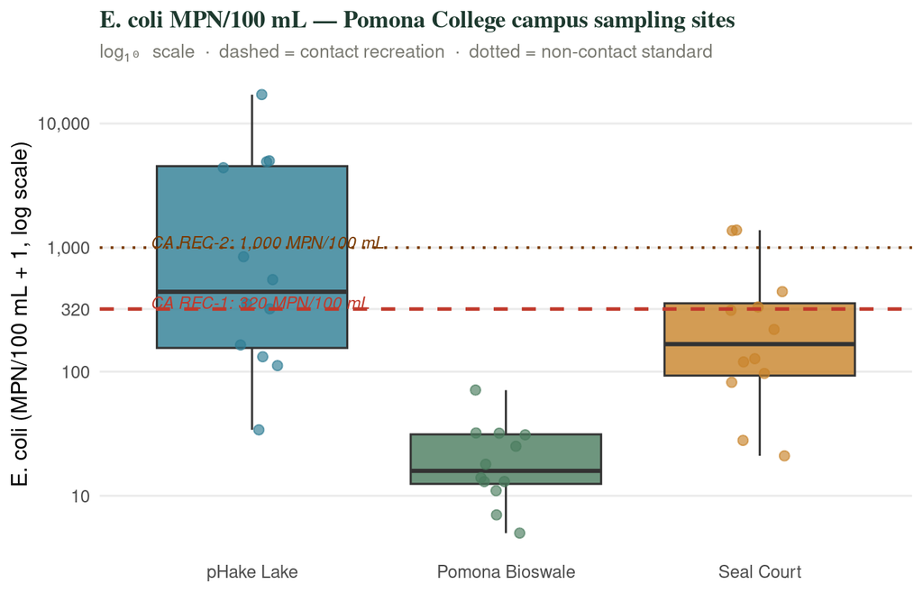

```r
site_colors <- c(
  "pHake Lake"      = "#2e7d94",
  "Seal Court"      = "#c8832a",
  "Pomona Bioswale" = "#4a7c5e"
)

ggplot(MPN_data, aes(x = Site_ID, y = EC_MPN + 1, fill = Site_ID)) +
  geom_boxplot(alpha = 0.8, outlier.shape = 21, outlier.size = 2.5,
               outlier.fill = "white") +
  geom_jitter(width = 0.12, size = 2.2, alpha = 0.65,
              aes(color = Site_ID)) +
  # California Basin Plan REC-1 single-sample standard
  geom_hline(yintercept = 320, linetype = "dashed",
             color = "#c0392b", linewidth = 0.9) +
  annotate("text", x = 0.6, y = 360,
           label = "CA REC-1: 320 MPN/100 mL",
           color = "#c0392b", hjust = 0, size = 3.2, fontface = "italic") +
  geom_hline(yintercept = 1000, linetype = "dotted",
             color = "#7a3a00", linewidth = 0.7) +
  annotate("text", x = 0.6, y = 1100,
           label = "CA REC-2: 1,000 MPN/100 mL",
           color = "#7a3a00", hjust = 0, size = 3.2, fontface = "italic") +
  scale_y_log10(
    labels = scales::comma,
    breaks = c(1, 10, 100, 320, 1000, 10000)
  ) +
  scale_fill_manual(values = site_colors,  guide = "none") +
  scale_color_manual(values = site_colors, guide = "none") +
  labs(
    title    = "E. coli MPN/100 mL — Pomona College campus sampling sites",
    subtitle = "log\u2081\u2080 scale  \u00b7  dashed = contact recreation  \u00b7  dotted = non-contact standard",
    x = NULL, y = "E. coli (MPN/100 mL + 1, log scale)"
  ) +
  theme_minimal(base_size = 12) +
  theme(
    plot.title    = element_text(family = "serif", face = "bold",
                                 color = "#1e3a2f", size = 13),
    plot.subtitle = element_text(color = "#7a7a72", size = 10),
    panel.grid.major.x = element_blank(),
    panel.grid.minor   = element_blank()
  )
```